# Reproducible Research: Peer Assessment 1

## Loading and preprocessing the data

```r
fname <- "activity.csv"
raw <- read.csv(fname, stringsAsFactors=FALSE)
```

- steps: Number of steps taking in a 5-minute interval (missing values are coded as NA)
- date: The date on which the measurement was taken in YYYY-MM-DD format
- interval: Identifier for the 5-minute interval in which measurement was taken
- 17568 == 2 months or 61 days * 288 readings per day
- (24 hrs/day * 60 min/hr)/5 min = 288, 5 minute intervals per 24 hr day
- Therefore there are 288 readings per day * 61 days (Oct and Nov) == 17568

Validate date range

```r
range(raw$date) # 10-1 thru 11-31
```

Count days in each month

```r
dom <- unique(as.Date(raw$date,"%Y-%m-%d")); dom
length(dom) #61 days
```

Readings per day

```r
table(raw$date)
```

Every 5 min interval, exists across all 61 days

```r
table(raw$interval)
```

How many missing step values"

```r
sum(is.na(raw$steps)) # 2304 NAs
dim(raw[raw$steps==0,]) # 13318
```

Convert date to Date type

```r
class(raw$date)
raw$date <- as.Date(raw$date,"%Y-%m-%d")
class(raw$date)
```

Remove NAs

```r
data <- raw[!is.na(raw$steps),]
data
dim(data) # 15264   [17568-2304==15264]
```

Count days after removing NAs

```r
dom <- unique(as.Date(data$date,"%Y-%m-%d")); dom
length(dom) #53 days
```

Convert date to a factor

```r
data$date <- factor(data$date)
```

## What is mean total number of steps taken per day (ignoring NAs)?

- Total steps: 57,0608
- Total days: 53
- Mean total steps: 10766.19
- Median steps: 10765

```r
sum(data$steps)
steps_per_day <- aggregate(data$steps, list(data$date), sum)
sum(steps_per_day$x)
mean(steps_per_day$x)
```

# Histogram

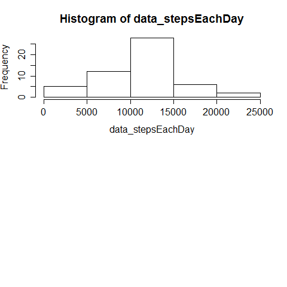

## What is the average daily activity pattern?

- average number of steps taken for each 5 min. interval across all days
- time series plot of this result
- which interval has the highest average steps?

```r
datainterval<-(aggregate(data[,1], by=list(data$interval), mean))
names(datainterval)<- c("interval","avgsteps")
```

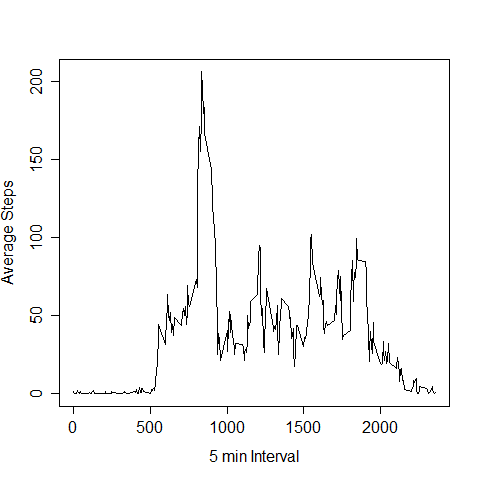

Interval 835 has the highest average steps at 206.17

```r
datainterval[datainterval$avgsteps==max(datainterval$avgsteps),]
```

## Imputing missing values

- report the total number of missing values in the dataset
- fill missing step values by inserting into each NA the related average steps for that interval
- create a histogram with the filled values dataset
- calculate total steps, mean and median using the new filled dataset

Missing step values

```r
sum(is.na(raw$steps)) # 2304 NAs
```

Fill missing vaues

```r
datafillNAs <- raw # create df with NAs
names(datainterval)<- c("interval","avgsteps")
for(i in which(is.na(datafillNAs$steps)==TRUE)){
    datafillNAs[i,"steps"] <- datainterval[datainterval$interval==datafillNAs[i,"interval"],"avgsteps"]
}
```

Histogram of filled data

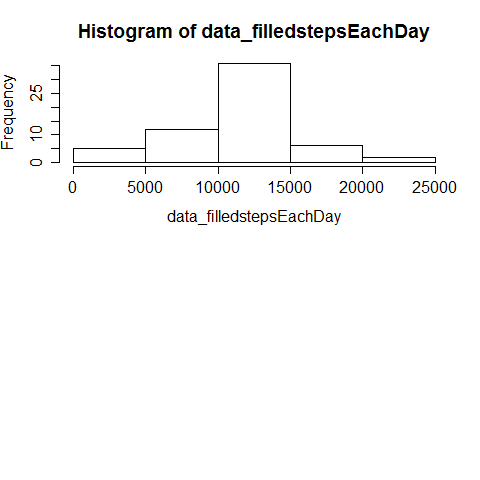

Calculate values for filled dataset to comparewith missing values dataset * Total steps: 656737.5

```r
data_filledstepsEachDay <- tapply(datafillNAs$steps, datafillNAs$date, FUN=sum)
sum(data_filledstepsEachDay)
```

- Mean: 10766.19

```r
mean(data_filledstepsEachDay)
```

- Median: 10766.19

```r
median(data_filledstepsEachDay)
```

# Do these values differ from the estimates from the first part of the assignment?

# What is the impact of imputing missing data on the estimates of the total daily number of steps?

## Are there differences in activity patterns between weekdays and weekends?

- create subsets of weekday and weekend data
- create factor variable in the dataset with two levels – “weekday” and “weekend”
- panel plot a time series for the 5-minute interval and average number of steps (across all weekday days or weekend days)

Subsets by weekend and weekday and plotted for comparison

```r
data_weekday<- tapply(datafillNAs[weekdays(datafillNAs$date)!="Saturday"&weekdays(datafillNAs$date)!="Sunday","steps"], datafillNAs[weekdays(datafillNAs$date)!="Saturday"&weekdays(datafillNAs$date)!="Sunday","date"],FUN=mean)
data_weekend<- tapply(datafillNAs[weekdays(datafillNAs$date)=="Saturday"|weekdays(datafillNAs$date)=="Sunday","steps"], datafillNAs[weekdays(datafillNAs$date)=="Saturday"|weekdays(datafillNAs$date)=="Sunday","date"],FUN=mean)

par(mfrow=c(2,1))
hist(data_weekday,breaks=30)
hist(data_weekend,breaks=30)
```

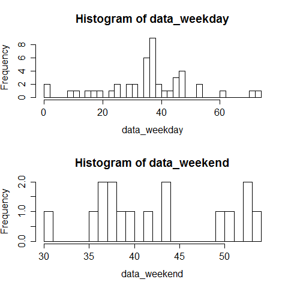

Factor for weekday and weekend

```r
wkDay <- c('Monday','Tuesday','Wednesday','Thursday','Friday')
datafillNAs$WD_WE <- factor((weekdays(datafillNAs$date) %in% wkDay), levels=c(FALSE,TRUE), labels=c('weekend','weekday'))
```

Panel plot time series for weekend and weekday data

```r
par(mfrow=c(2,1))
plot(datafillNAs[datafillNAs$WD_WE=="weekday","interval"], datafillNAs[datafillNAs$WD_WE=="weekday","steps"],
     type="l",
     xlab="5 min Interval",
     ylab="Average Steps"
)
plot(datafillNAs[datafillNAs$WD_WE=="weekend","interval"], datafillNAs[datafillNAs$WD_WE=="weekend","steps"],
     type="l",
     xlab="5 min Interval",
     ylab="Average Steps"
)
```

[figure not shown]